# Лабораторна робота №3. Побудова регресійних моделей

**Мета:** *Мета: Засвоєння базових принципів, знайомство з інструментами та набуття навичок побудови моделей регресії на рівні технології на основи статистичного підходу та моделей машинного навчання засобами мови програмування R та колекції пакетів `dplyr`, `ggplot2`.*

## 1 Підготовка даних до аналізу

### 1.1 Імпорт та попередній огляд

```r
library(dplyr)
library(ggplot2)
library(knitr)

library(readxl)
raw_data <- read_excel("data/hw.xlsx")

colnames(raw_data) <- c("Height", "Weight", "Gender")

glimpse(raw_data)
```

```
Rows: 200
Columns: 3
$ Height <dbl> 175, 168, 173, 170, 171, 180, 188, 171, 190, 170, 178, 170, 175, 175,…
$ Weight <dbl> 87, 84, 63, 75, 72, 74, 85, 74, 76, 67, 80, 60, 75, 70, 84, 76, 89, 8…
$ Gender <chr> "Man", "Man", "Man", "Man", "Man", "Man", "Man", "Man", "Man", "Man",…
```

```r
head(raw_data)
```

| Height | Weight | Gender |
| --- | --- | --- |
| 175 | 87 | Man |
| 168 | 84 | Man |
| 173 | 63 | Man |
| 170 | 75 | Man |
| 171 | 72 | Man |
| 180 | 74 | Man |

### 1.2 Очищення та фільтрація

Далі необхідно дослідити залежність маси тіла від зросту для жінок. Також перевіримо дані на наявність аномальних викидів.

```r
women_df <- raw_data %>%
  filter(Gender == "Woman") %>%
  select(Height, Weight)

na_count <- sum(is.na(women_df))
cat("Кількість пропущених значень:", na_count, "\n")
```

```
Кількість пропущених значень: 0
```

```r
summary(women_df)
```

```
     Height          Weight
 Min.   :146.0   Min.   : 44.00
 1st Qu.:164.0   1st Qu.: 55.00
 Median :169.0   Median : 62.00
 Mean   :168.7   Mean   : 63.78
 3rd Qu.:174.0   3rd Qu.: 70.00
 Max.   :200.0   Max.   :167.00
```

## 2 Розвідувальний аналіз (EDA)

Перед побудовою математичної моделі необхідно візуально оцінити форму залежності.

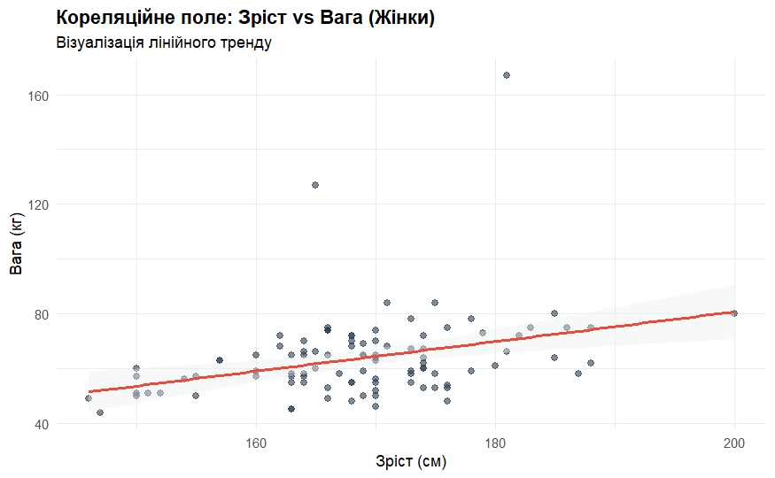

```r
ggplot(women_df, aes(x = Height, y = Weight)) +
  geom_point(color = "#2c3e50", alpha = 0.6, size = 2) +
  geom_smooth(method = "lm", color = "#e74c3c", fill = "#ecf0f1") +
  labs(
    title = "Кореляційне поле: Зріст vs Вага (Жінки)",
    subtitle = "Візуалізація лінійного тренду",
    x = "Зріст (см)",
    y = "Вага (кг)"
  ) +
  theme_minimal() +
  theme(plot.title = element_text(face = "bold"))
```

```r
cor_val <- cor(women_df$Height, women_df$Weight)
```

## 3 Побудова регресійної моделі

Створимо модель парної лінійної регресії

```r
linear_model <- lm(Weight ~ Height, data = women_df)

summary(linear_model)
```

```
Call:
lm(formula = Weight ~ Height, data = women_df)

Residuals:
    Min      1Q  Median      3Q     Max
-19.732  -8.181  -1.105   5.131  96.560

Coefficients:
            Estimate Std. Error t value Pr(>|t|)
(Intercept) -27.5600    25.6938  -1.073 0.286071
Height        0.5414     0.1521   3.561 0.000573 ***
---
Signif. codes:  0 ‘***’ 0.001 ‘**’ 0.01 ‘*’ 0.05 ‘.’ 0.1 ‘ ’ 1

Residual standard error: 14.6 on 98 degrees of freedom
Multiple R-squared:  0.1146,    Adjusted R-squared:  0.1055
F-statistic: 12.68 on 1 and 98 DF,  p-value: 0.0005726
```

Аналіз коефіцієнтів:

**Estimate (Height)**: Коефіцієнт при змінній зросту позитивний. Його значення вказує на те, на скільки кілограмів в середньому збільшується вага при збільшенні зросту на 1 см.

**P-value**: Значення значно менше 0.05, що свідчить про статистичну значущість моделі.

## 4 Прогнозування

Виконаємо прогноз ваги для заданих значень зросту (наприклад: 155, 165, 175 см) з розрахунком довірчих інтервалів.

```r
test_heights <- data.frame(Height = c(155, 165, 175))

predictions <- predict(linear_model, newdata = test_heights, interval = "confidence")

final_res <- cbind(test_heights, predictions)

kable(final_res,
      col.names = c("Зріст (см)", "Прогноз ваги (кг)", "Нижня межа (95%)", "Верхня межа (95%)"),
      digits = 1,
      caption = "Таблиця 1. Результати прогнозування")
```

Таблиця 1. Результати прогнозування

| Зріст (см) | Прогноз ваги (кг) | Нижня межа (95%) | Верхня межа (95%) |
| --- | --- | --- | --- |
| 155 | 56.4 | 51.3 | 61.4 |
| 165 | 61.8 | 58.7 | 64.9 |
| 175 | 67.2 | 63.7 | 70.7 |

## 5 Висновки

У ході лабораторної роботи на реальному датасеті hw було побудовано регресійну модель залежності ваги від зросту для жіночої статі. Встановлено, що зріст є значущим предиктором для ваги. Побудована модель адекватно описує загальну тенденцію, хоча наявність розкиду даних свідчить про вплив інших факторів, які не враховані у простій парній регресії.